# What Really Drives House Prices? Comparing Unchangeable and Changeable Factors in New York State

Group L91G03

Anne Do, Arielle Melamed, Serafina Aurelia, Eric Lee, Haresh Kumararajah

## Approach

- Problem Statement: **To what extent do immutable property characteristics, compared to changeable attributes, explain housing price variation?**
- Through who’s lens should we view the data?
- Perspectives:
  - A homeowner considering possible renovations
  - A buyer looking to make an informed decision
- What can the homeowner do to improve price of their house?
- How much attention should buyer show towards “unchageable” characteristics? A chance of underevaluation?

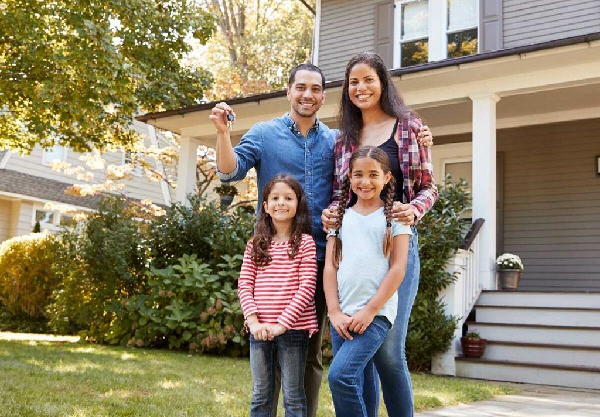

## Dataset Overview - Saratoga Housing Data

- **1734 observations**
- **17 variables**
- **Dependent Variable:** Price
- There are no missing values in the data
- Saratoga County, New York State, 2006
- Collected for a case study: “How much is a Fireplace Worth?”

| Column | Unit | Notes |
| --- | --- | --- |
| Lot.Size | Acres | - |
| Living.Area | sq^2 | - |
| Pct.College | % | % of Neighborhood with College Education |
| Test | N/A | Random |

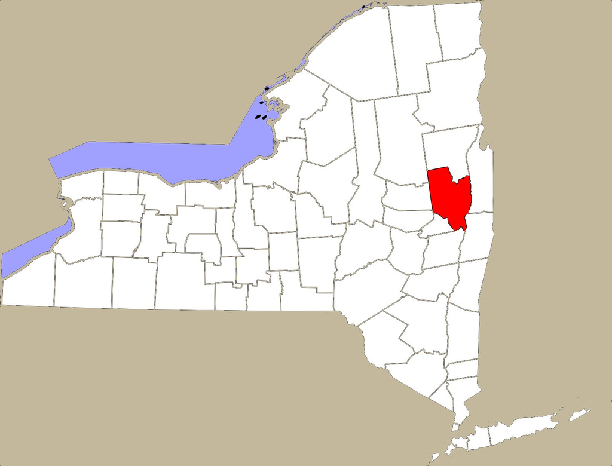

## Data Cleaning

1. Filter invalid data: 0 Lot Size
2. Remove inconsistent data where Age = 0 and New.Construct = 0
3. Convert certain variables from text/numeric to a categorical data type (Waterfront, New Construction, Central Air, Fuel Type, Heat Type, Sewer Type)
4. Log transformation for variables with skewed data: Price, Lot Size, Age, Land Value

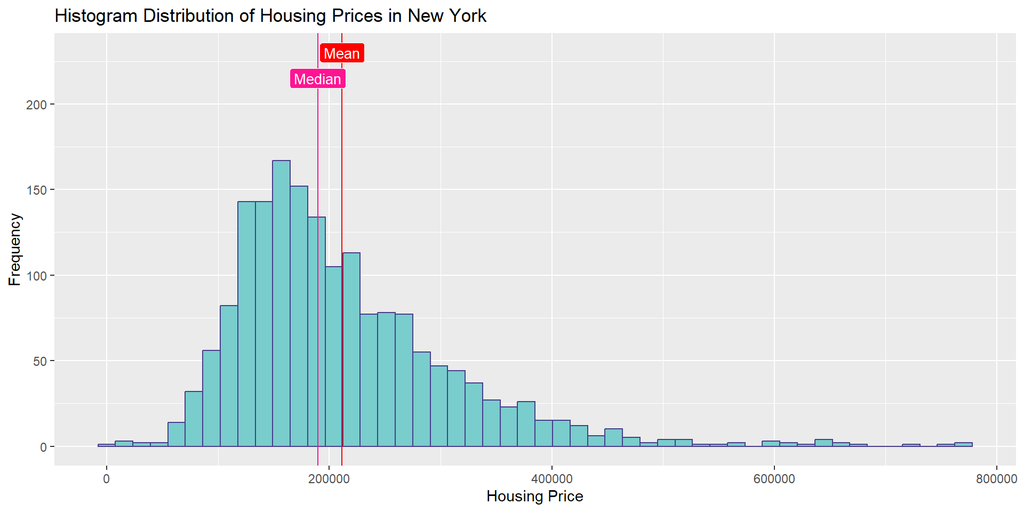

## Variable Groupings - Changeable and Unchangeable

| Unchangeable | Changeable |
| --- | --- |
| Lot.Size | Living.Area |
| Waterfront | Bathrooms |
| Age | Bedrooms |
| Land.Value | Rooms |
| Pct.College | Central.Air |
|  | New.Construct |
|  | Heat.Type |
|  | Fuel.Type |
|  | Fireplaces |
|  | Sewer.Type |

## Variable Selection Approach - Stepwise

- We used **stepwise selection** methods to identify the most influential variables.
- Three approaches tested: **Forward**, **Backward**, and **Stepwise (both)**
- Each approach adds or removes variables based on the **Akaike Information Criterion (AIC)**.

## Stepwise Results

Forward, Backward, and Stepwise (Full Model)

| Model | R2 | Adj_R2 | AIC |
| --- | --- | --- | --- |
| Forward | 0.593 | 0.589 | 638.4 |
| Backward | 0.593 | 0.589 | 635.2 |
| Stepwise | 0.593 | 0.589 | 635.2 |

**Final Model (Backward/Stepwise Selection)**

Housing.Price ~  
Waterfront + New.Construct + Central.Air + Fuel.Type.Gas +  
Fuel.Type.Wood + Living.Area + Bathrooms + Log.Age + Log.Land.Value

## Model Evaluation: In-Sample Performance Test

- The Living Area model is the most best among the single-predictor models.
- The selected model achieves a higher R² (around 0.59), indicating a better overall fit.

| Model | R² | Adjusted R² | AIC |
| --- | --- | --- | --- |
| Living Area | 0.467 | 0.466 | 1062.308 |
| Bathrooms | 0.341 | 0.341 | 1417.040 |
| Selected Model | 0.587 | 0.584 | 653.282 |
| Changeable Variables | 0.502 | 0.500 | 959.826 |
| Unchangeable Variables | 0.330 | 0.328 | 1450.892 |

## Out-of-Sample Performance Test

- Living Area alone was the most effective single predictor of price.
- This indicates that housing price is influenced by multiple property characteristics rather than any single factor.

| Model | RMSE | MAE |
| --- | --- | --- |
| Living Area | 0.33 | 0.22 |
| Bathrooms | 0.37 | 0.26 |
| Selected Model | 0.31 | 0.21 |
| Changable Variables | 0.31 | 0.21 |
| Unchagable Variables | 0.40 | 0.28 |

## K-fold Cross Validation

[output not shown]

## Model Stability and Variable Inclusion

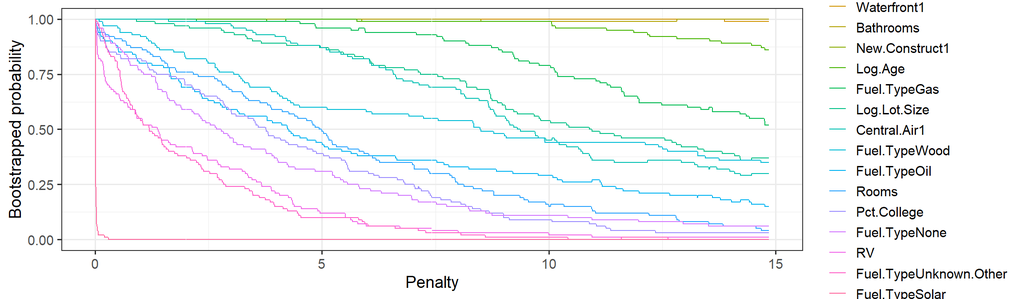

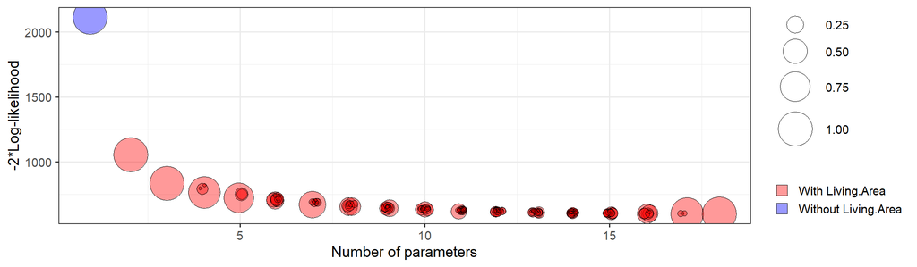

## Assumption Check - Linearity

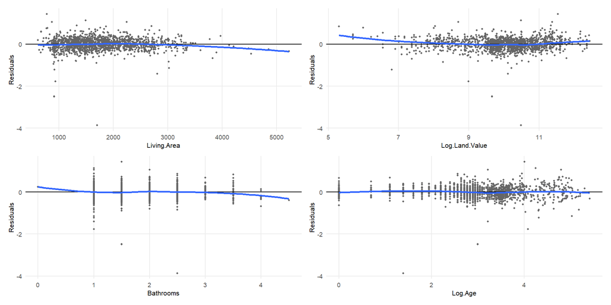

The residuals are relatively randomly scattered around the zero lines. Hence, the linearity assumption is satisfied.

## Assumption Check - Homoscedasticity

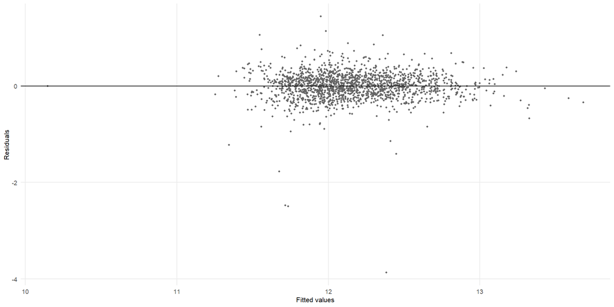

The spread looks reasonably constant over the range of fitted log price values. Hence, the homoscedasticity assumption for the residuals is satisfied.

## Assumption Check - Normality

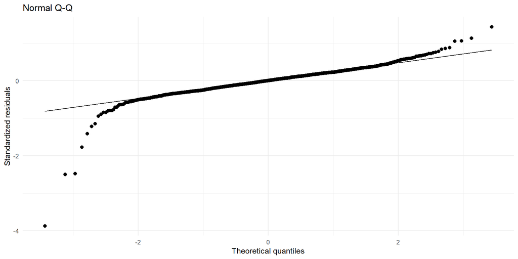

## Assumption Check - Multicollinearity

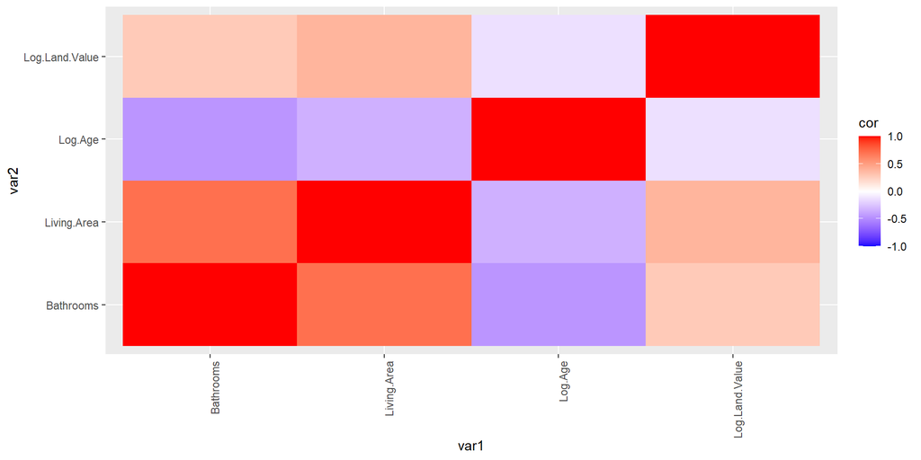

There is no multicollinearity as no pair of predictors are highly correlated (i.e., having |r| > 0.8).

## Discussion: Coefficients

| Variable | Change in unit | Impact on price (%) |
| --- | --- | --- |
| Living area | +100 sq ft | +2.89% |
| Land value | +10% | +1.18% |
| Bathrooms | +1 | +10.26% |
| Waterfront | Yes | +76.03% |
| Central air | Yes | +5.82% |
| Fuel: gas | Yes | +8.66% |
| Fuel: wood | Yes | -64.12% |
| Age | +10% | -0.50% |
| New construction | Yes | -21.82% |

[figure not shown]

## Key Takeaways - Changeable attributes

Useful for *homeowners* looking to renovate and increase the value of their house.

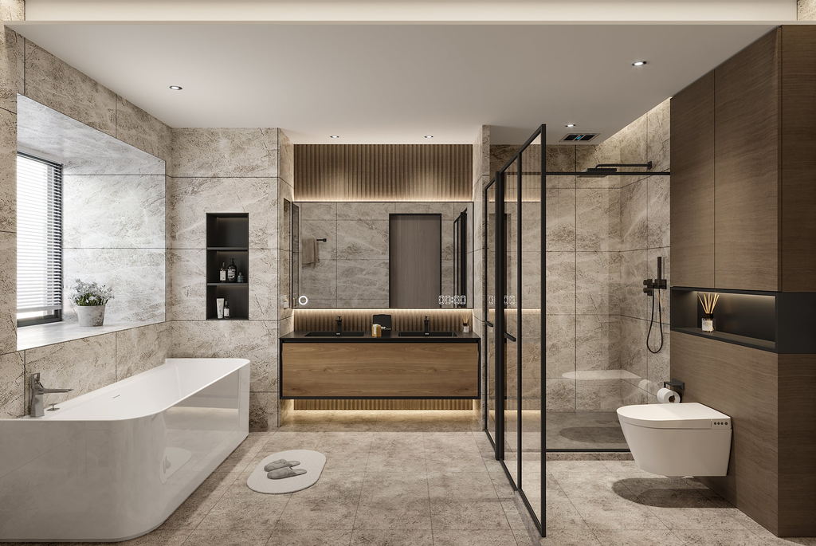

## Key Takeaways - Immutable attributes

Useful for *prospective buyers/sellers*.

- Waterfront is associated the highest increase in housing price

**Changeable and unchangeable attributes both matter.**

- For both users, this helps set realistic expectations
- Buyers: renovation is not everything
- Homeowners: don’t be complacent if you have a nice waterfront

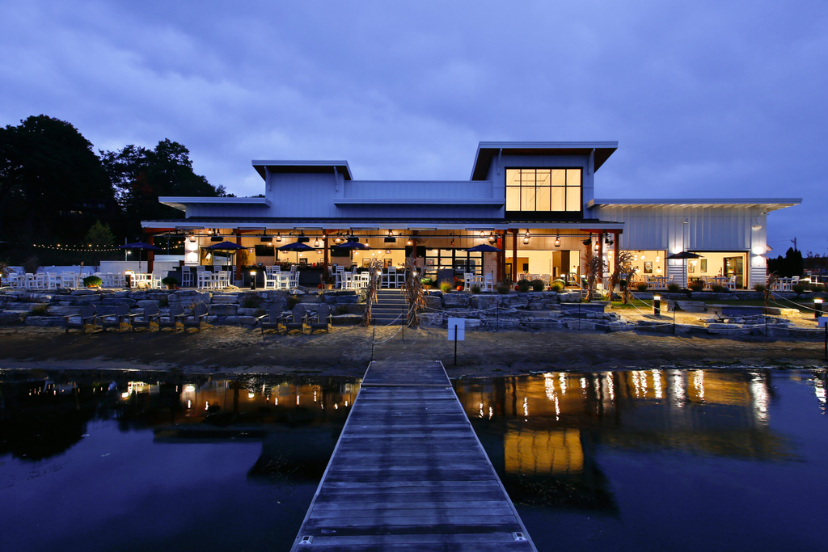

## Limitations

#### Representativeness

- 2006, GFC
- Saratoga ≠ NYC: suburban ≠ urban

Unrecorded variables

Risk of overfitting

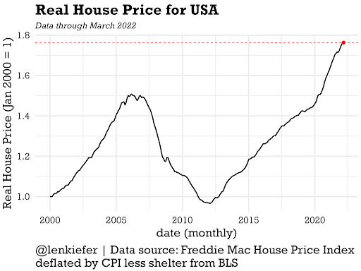

## Future Work

- More recent / time series
- More variables
- Interactive geographic visualisations

[figure not shown]